# Scraping Structured Formats

## Before we begin

[figure not shown]

## Introduction

**Where are we now?**  
- We know how to imitate a browser, thus how to collect html from a webpage  
- We know how to restructure this information into a tree-shaped text - But it still looks bulky and we would like to only extract some information  
(ex. on a website about movies, only retain titles and directors of films)

## Introduction

**From the page to the relevant data**

**Two main options**  
- Selecting from the structure of the page  
→ Using requests that take advantage of the structure of the page (today)

- Selecting from regularities in the text  
→ Using regular expressions (tomorrow)

## Introduction

**From the page to the relevant data**

**Two main options**

**Using Xpath (and css)**  
- Xpath is a language (yet another one!) to make queries  
- Xpath queries the tree structure of a page  
- From that, it selects elements into this structure

## Outline

**1. Principles of Xpath**  
- A quick reminder on HTML (and markup languages)  
- A path to a node  
- There are more than one path

**2. Selection**  
- How to select  
- What to select  
- How to in R

**3. Remarks on Automation**  
- A few handy functions  
- Inspect your code  
- Cheat!

## **Principles of Xpath**

## Reminder about markup languages

HTML is a markup language  
<html>  
<body>  
<h1> Hey there </h1>  
<p> This is a paragraph with <a href=“link”> a link </a>  
</body>  
</html>

## Reminder about markup languages

HTML is made up of nodes (two tags), which have  
- A type (a, span, div, etc)  
- A content  
- They may have attributes (href,class, id,etc)  
→ We want to select the content OR the attributes  
<html>  
<body>  
<h1> Hey there </h1>  
<p> This is a paragraph with <a href=“link”> a link </a>  
</body>  
</html>

## Reminder about markup languages

An example of XML

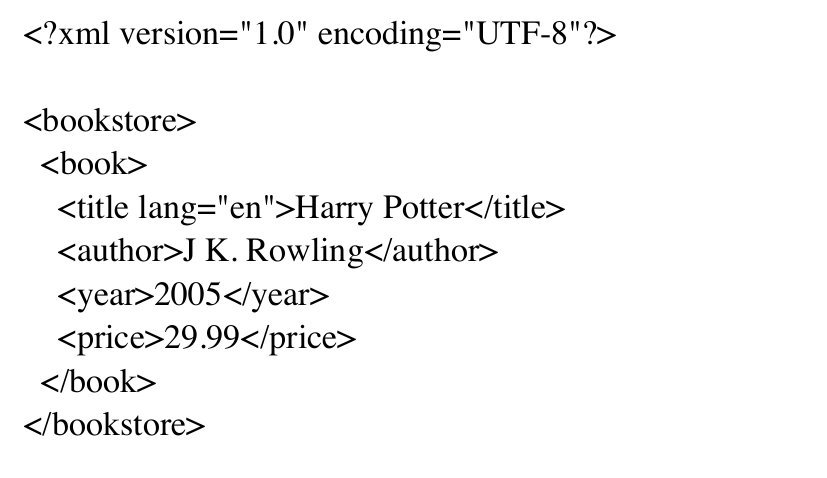

## Xpath, a path to a nod

Xpath is nothing more than a path (= “an address”)

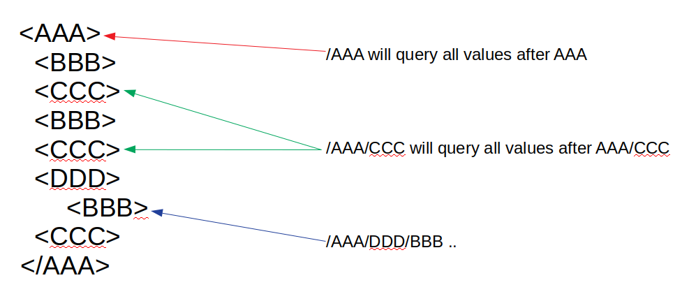

## There are several paths to one node

- The simplest path goes from the root to the node
- But you can select from any node (//DDD/BBB)
- You can also skip a node (/AAA//BBB)
- But pay attention: one path may select several nodes

[figure not shown]

## **Selection in Xpath**

## There are three principles of selection

1. Absolute (all the way down) \ relative
2. Going down, going up
3. Selecting from content ← 95% of cases

## There are three principles of selection

*Absolute vs. relative*

- With the absolute path, you write the path all the way down (your path starts with \)
- With the relative, you start at a point in the tree, and you continue the path (your path starts with \\)

## There are three principles of selection

*Going down \ Going up*

- While going down may be the most common way, sometimes you have to start at one point, and climb your way up.

## There are three principles of selection

*Selection from content*

Most of the time, we only want to select the nodes that match a certain conditions (all the titles in a page)

This condition is written between [ ], and is related to the text, or to an attribute (@class, @href, …)

\\div[@class = “book”] : content from all div whose class is book

## Selection in Xpath

**Four main operators**

How to select

- \ Child → Direct descendant
- \\ Descendant → Anywhere below

What to select

- [] Condition
- @ Attribute

## Selection in Xpath

[output not shown]

## Selection in Xpath

| Xpath | Action |
| --- | --- |
| /a | All hypertext links **at the root level** |
| //a | All the hypertext links |
| //div/a | All the hyperlinks in the div (just after) |
| //div//a | All the hyperlinks anywhere in the div |
| //a[contains(text(), ‘sociology’)] | All the links that contain ‘sociology’ |

## What to select?

Distinction between value and attribute  
- Value: what is between the two tags

<TAG>content</TAG>

- Attribute: what is contained inside the tag

<a href= “www.ollion.cnrs.fr”> Blablabla </a>

## To go further

Joker: /* → any type of tag Ex. /div/*/a

Conditions: contains(), starts-with(), ends-with()

Navigation: child(), parent(), following-sibling()

Number of descendants: count()

## How-to in R

**A few handy functions**

**html_elements(PAGE, xpath=‘PATH’)**

PAGE: the (restructured) page  
PATH: the path

## How-to in R

**A few handy functions**

So:  
read_html(“https://sicss.io/2022/paris/schedule”)  
%>%  
html_elements(xpath=‘//li’)

will return all elements stored as a list

## How-to in R

**A few handy functions**

- html_table() #Extracts tables
- html_text() #Extracts raw text (faster)
- html_text2() #Uses formating, nicer
- html_forms() #need to add a login, enter a query?

And one important extra function  
- html_attrs(“href”) #To get the attributes

## How-to in R

**Inspect your code**